# Diagnóstico de Rentabilidad — Kapitalya FX

Qué gana realmente la casa de cambio, y dónde está el dinero que se deja sobre la mesa

Autor/a

Sergio Denis Troche Mayta

Fecha de publicación

1 de julio de 2026

Resumen

Este informe reconstruye la **ganancia real** de la casa de cambio a partir de 4.570 transacciones registradas entre 2025-06-23 a 2026-07-01, extraídas automáticamente de los registros operativos. Aplica el método de **costo promedio móvil** para calcular el margen efectivo por operación —no una estimación— y cuantifica las oportunidades de mejora.

| **Negocio** | Casa de cambio de divisas — La Paz, Bolivia |
| --- | --- |
| **Período analizado** | 2025-06-23 a 2026-07-01 (280 días operados) |
| **Transacciones** | 4.570 (3.536 compras · 1.034 ventas) |
| **Fuente** | Registros operativos (Google Sheets), extracción automatizada |
| **Método** | Costo promedio móvil por divisa |

# 1 Resumen ejecutivo

En los últimos 280 días operados, el negocio generó una **ganancia realizada de Bs 381.132** sobre un volumen vendido de Bs 9.948.017 — un **margen efectivo del 3.83%** y un promedio de **Bs 1.361 por día**.

- **El dólar es el motor.** El USD aporta Bs 315.611 —el **83%** de toda la ganancia.
- **La estacionalidad es fuerte.** El mejor mes *por ganancia de trading* (dic-25) rindió Bs 69.556; meses flojos rondan un tercio de eso.
- **Hay dinero dejado sobre la mesa.** 83 ventas (8.0% del total) se cerraron **por debajo del costo**, una pérdida acumulada de Bs 21.313.

**ImportanteDos métricas distintas — no confundir**

Este informe mide **ganancia de trading** (margen sobre ventas), y solo cubre **desde junio 2025** (cuando empezó el registro transacción por transacción). Es **distinta** del *cambio de capital* que lleva la planilla de Control: esa incluye gastos, retiros e inyecciones, y por esa métrica el mejor mes es **mayo 2025**. Ambas son correctas; miden cosas diferentes. La diferencia entre el margen de trading y el crecimiento de capital es, justamente, lo que se va en **gastos y retiros** (ver «Panorama financiero neto»).

# 2 Metodología y datos

## 2.1 De dónde salen los números

Los datos provienen directamente de los registros operativos del negocio (los mismos Google Sheets que alimentan Power BI). Un proceso de extracción automatizado lee 4.570 transacciones de 2025 y 2026, unifica los formatos heterogéneos y descarta solo 14 filas con datos inconsistentes. Al refrescar la fuente, todo este informe se recalcula con un comando.

## 2.2 Cómo se calcula la ganancia “real”

No se usa un margen fijo asumido. Para **cada venta** se calcula:

$$\text{ganancia} = (\text{tasa de venta} - \text{costo promedio del inventario}) \times \text{cantidad}$$

El **costo promedio del inventario** se actualiza con cada compra (promedio móvil ponderado). Así, una venta solo es “ganadora” si supera lo que realmente costó adquirir esa divisa.

# 3 Hallazgo 1 — Rentabilidad global y estacionalidad

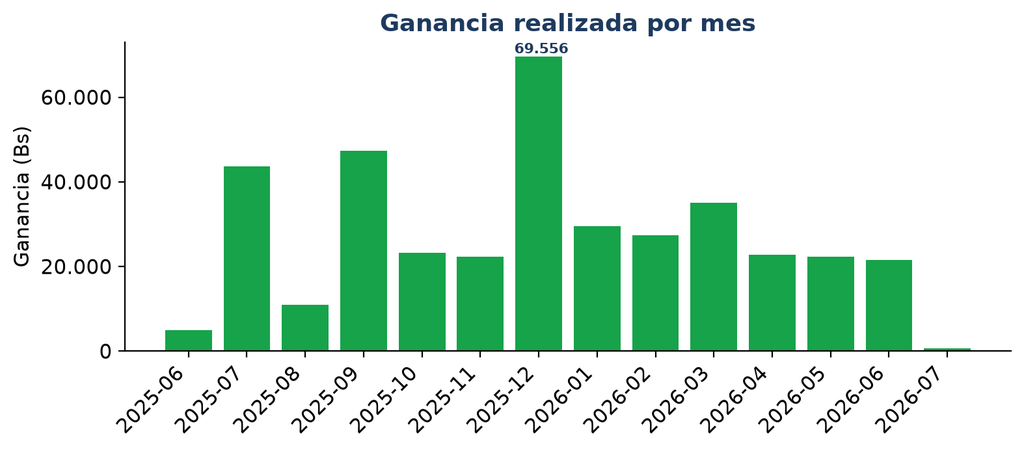

Ganancia realizada por mes

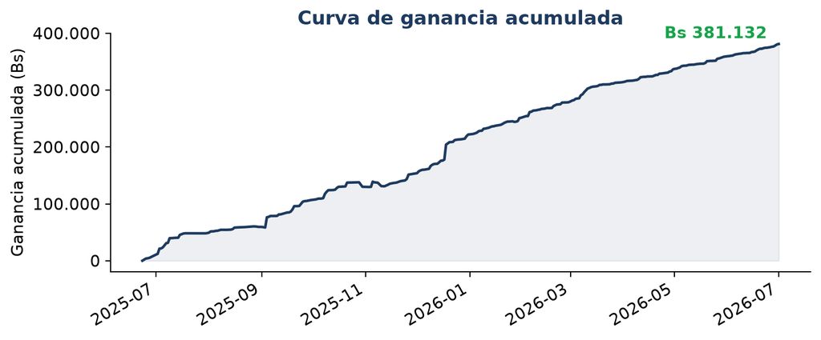

Curva de ganancia acumulada

> **Lectura para el dueño:** el pico de dic-25 (Bs 69.556) frente al piso de jul-26 (Bs 719) muestra que la demanda no es plana. Conviene tener **más inventario y mejor spread** en los meses fuertes.

# 4 Las dos eras del negocio

El negocio tiene **dos etapas de registro**, y conviene leerlas con la métrica correcta de cada una:

- **Era de control de capital (feb–may 2025).** Manejo manual; se medía el resultado tomando **fotos periódicas del capital**. No hay detalle transacción por transacción, pero sí una serie de balance confiable.
- **Era transaccional (jun 2025 → hoy).** Cada operación queda registrada.

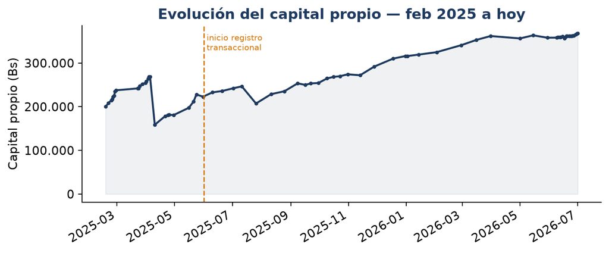

Evolución del capital propio — feb 2025 a hoy

El capital propio creció de Bs 200.000 (feb 2025) a Bs 367.810 (al 2026-07-01). Por la métrica de cambio mensual, el mejor mes fue **may-25** (+Bs 42.019). *(Los acreedores van aparte; ver el recuadro siguiente.)*

**ImportanteCuánto del capital es propio y cuánto de acreedores**

Al 2026-07-01:

| Concepto | Bs | % |
| --- | --- | --- |
| **Capital propio** | **367.810** | 63% |
| Acreedores (terceros) | 215.000 | 37% |
| **= Total gestionado** | **582.810** | 100% |

Operar con capital de terceros **amplifica el retorno sobre tu dinero** siempre que el margen de trading supere el costo de esos fondos.

## 4.1 Margen de trading ≠ crecimiento de capital

| Concepto (jun–dic 2025) | Monto (Bs) |
| --- | --- |
| Margen de trading (este informe) | Bs 221.928 |
| Crecimiento de capital (Control) | Bs 93.088 |
| **Brecha → gastos + retiros** | **Bs 128.840** |

# 5 Hallazgo 2 — La ganancia está concentrada en el USD

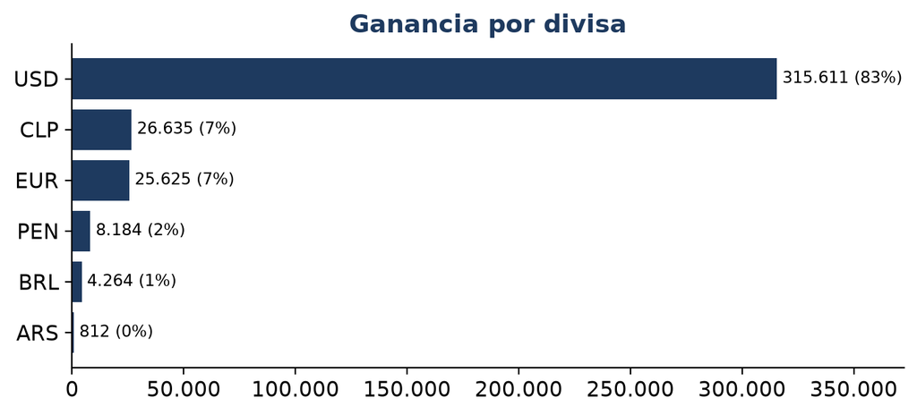

Ganancia por divisa

El **83%** de la ganancia viene del dólar. El spread del USD es la palanca #1, y el riesgo también se concentra.

# 6 Hallazgo 3 — Productividad por responsable

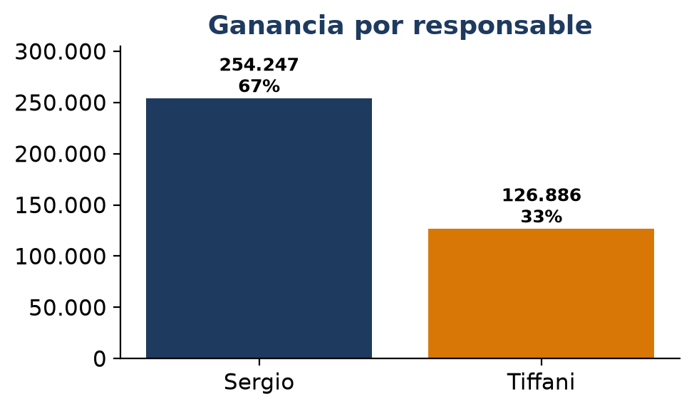

Ganancia por responsable

Sergio genera Bs 254.247 (67%) y Tiffani Bs 126.886 (33%).

# 7 Hallazgo 4 — Dinero dejado sobre la mesa

83 de 1.034 ventas (8.0%) se cerraron **bajo el costo promedio del inventario**, sumando una pérdida de **Bs 21.313**. La mayor fue el 2025-11-10: 11.000 USD vendidos a Bs 10.50, una pérdida de Bs 5.148.

Un **control de tasa mínima** en el punto de venta y una **validación de captura** recuperan gran parte de esto.

# 8 Panorama financiero neto — a dónde va el dinero

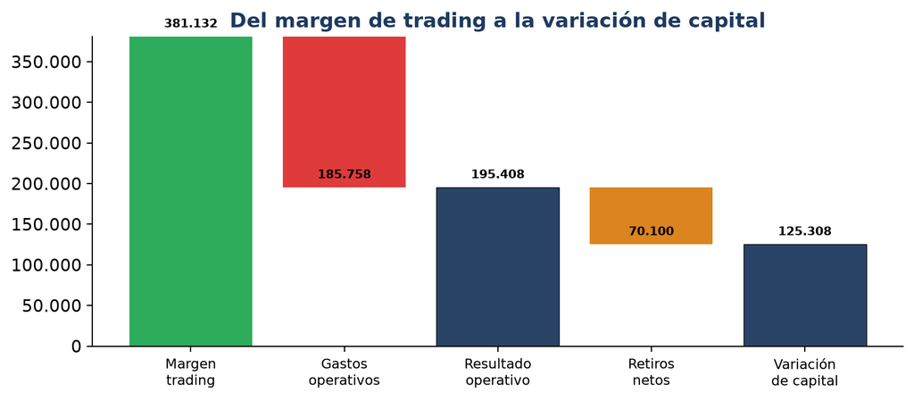

De dónde sale y a dónde va el dinero

[output not shown]

> **Lo que esto significa:** el negocio de cambio **es sólidamente rentable** — generó **Bs 195.408** de resultado operativo. Tras retirar Bs 70.100 en efectivo, el capital igual creció Bs 125.308.

El mayor gasto operativo es **Compras - Varios** (Bs 64.690).

**NotaEl vehículo no fue una pérdida del negocio**

La compra del **VW Gol (Bs 111.700)** ocurrió en **abril 2025**, en la era manual. No es una pérdida operativa: es capital convertido en un activo. Por eso se excluye del resultado operativo del período transaccional.

# 9 Limitaciones de los datos

- **No hay hora de la transacción** (solo fecha). No se puede calcular la “hora más rentable” hasta que el registro capture la hora.
- **No hay identificación de cliente** en el histórico, así que no se puede medir retención ni segmentar clientes grandes todavía.

# 10 Roadmap de mejoras — priorizado por impacto real

| Prioridad | Acción | Impacto estimado | Esfuerzo |
| --- | --- | --- | --- |
| 1 | Tasa mínima + validación de captura | Recuperar gran parte de los Bs 21.313 | Bajo |
| 2 | Spread dinámico del USD | +0,5 pp de margen sobre el volumen USD | Medio |
| 3 | Capturar hora + cliente | Habilita hora pico y retención | Bajo |
| 4 | Control de inventario USD | Evita quiebres de stock en meses fuertes | Medio |
| 5 | Dashboard diario para el dueño | Visibilidad de ganancia real cada mañana | Medio |

# 11 Anexo — Reproducir este informe

```bash
cd forex-erp/docs/negocio/etl
python build.py
```

*Kapitalya FX · Diagnóstico generado sobre 4.570 transacciones reales · La Paz, Bolivia*